# Main file TFA exam (R part)

Lars Relund Nielsen

In the following, use R to answer the questions/assignments. Your solutions must be written up in a R Markdown (Rmd) file. This file must include your code and a (brief) comment for each question. For example, “The three companies with smalles profit are …” or “The plot shows that …”.

An R markdown template file is given in the appendix that you may use as a starting point.

You may load and use the following packages:

```r
library(tidyverse)
library(skimr)
```

# R - Assignment 1 (12%)

The euclidean distance between two points $p = (p_1,p_2)$ and $q = (q_1,q_2)$ can be calculated using formula
$$d(p,q) = \sqrt{(p_1-q_1)^2 + (p_2-q_2)^2}.$$

## Question 1

Calculate the distance between points $p = (10,10)$ and $q = (4,3)$ using the formula.

Guiding solution:

```r
p <- c(10,10)
q <- c(4,3)
sqrt((p[1] - q[1])^2 + (p[2] - q[2])^2)
```

```
## [1] 9.219544
```

The distance is 9.2195445.

## Question 2

Consider 4 points in a matrix (one in each row):

```r
p_mat <- matrix(c(0, 7, 8, 2, 10, 16, 8, 12), nrow = 4)
p_mat
```

```
##      [,1] [,2]
## [1,]    0   10
## [2,]    7   16
## [3,]    8    8
## [4,]    2   12
```

The distance matrix of `p_mat` is a 4 times 4 matrix where entry (i,j) contains the distance from the point in row `i` to the point in row `j`.

Calculate the distance matrix of `p_mat`.

Guiding solution:

```r
d_mat = matrix(NA, nrow = nrow(p_mat), ncol = nrow(p_mat))
for (i in 1:nrow(d_mat)) {
  for (j in 1:ncol(d_mat)) {
    # if (i>j) {d_mat[i,j] <- d_mat[j,i]; next}   # assume symmetric distances
    # if (!is.na(d_mat[i,j])) next          # value already calculated
    if (i==j) {d_mat[i,j] <- 0; next}
    d_mat[i,j] <- sqrt((p_mat[i,1] - p_mat[j,1])^2 + (p_mat[i,2] - p_mat[j,2])^2)
  }
}
d_mat
```

```
##          [,1]     [,2]     [,3]     [,4]
## [1,] 0.000000 9.219544 8.246211 2.828427
## [2,] 9.219544 0.000000 8.062258 6.403124
## [3,] 8.246211 8.062258 0.000000 7.211103
## [4,] 2.828427 6.403124 7.211103 0.000000
```

The distance matrix is given above.

## Question 3

Create a function `calc_distances` with the following features (implement as many as you can):

- Takes a matrix `p_mat` with a point in each row as input argument.
- Takes two additional input arguments `from` and `to` with default values `1:nrow(p_mat)`
- Return the distance matrix with values calculated for rows in the `from` input argument and columns in the `to` input argument. The other entries equals `NA`.
- The function should work for different `p_mat` (you may assume that the matrix always have two columns).

You may test your code using:

```r
p_mat <- matrix(c(10, 9, 15, 15, 11, 19, 12, 11, 7, 15), nrow = 5)
calc_distances(p_mat)
calc_distances(p_mat, to = 3:4)
calc_distances(p_mat, from = c(1, nrow(p_mat)), to = 3:4)
```

Guiding solution:

```r
calc_distances <- function(p_mat, from = 1:nrow(p_mat), to = 1:nrow(p_mat)) {
  d_mat <- matrix(NA, nrow = nrow(p_mat), ncol = nrow(p_mat))
  ite <- expand_grid(from = from, to = to)
  for (r in 1:nrow(ite)) {
    i <- ite$from[r]
    j <- ite$to[r]
    if (!is.na(d_mat[i,j])) next          # value already calculated
    if (i==j) {d_mat[i,j] <- 0; next}
    d_mat[i,j] <- sqrt((p_mat[i,1] - p_mat[j,1])^2 + (p_mat[i,2] - p_mat[j,2])^2)
  }
  return(d_mat)
}
p_mat <- matrix(c(10, 9, 15, 15, 11, 19, 12, 11, 7, 15), nrow = 5)
calc_distances(p_mat)
```

```
##           [,1]     [,2]     [,3]      [,4]     [,5]
## [1,]  0.000000 7.071068 9.433981 13.000000 4.123106
## [2,]  7.071068 0.000000 6.082763  7.810250 3.605551
## [3,]  9.433981 6.082763 0.000000  4.000000 5.656854
## [4,] 13.000000 7.810250 4.000000  0.000000 8.944272
## [5,]  4.123106 3.605551 5.656854  8.944272 0.000000
```

```r
calc_distances(p_mat, to = 3:4)
```

```
##      [,1] [,2]     [,3]      [,4] [,5]
## [1,]   NA   NA 9.433981 13.000000   NA
## [2,]   NA   NA 6.082763  7.810250   NA
## [3,]   NA   NA 0.000000  4.000000   NA
## [4,]   NA   NA 4.000000  0.000000   NA
## [5,]   NA   NA 5.656854  8.944272   NA
```

```r
calc_distances(p_mat, from = c(1, nrow(p_mat)), to = 3:4)
```

```
##      [,1] [,2]     [,3]      [,4] [,5]
## [1,]   NA   NA 9.433981 13.000000   NA
## [2,]   NA   NA       NA        NA   NA
## [3,]   NA   NA       NA        NA   NA
## [4,]   NA   NA       NA        NA   NA
## [5,]   NA   NA 5.656854  8.944272   NA
```

The function with test are given above.

# R - Assignment 2 (22%)

The dataset `companies`, given in the appendix, lists approx. 1000 of the world’s biggest companies, measured by sales, profits, assets and market value. The column/variables are:

- `name`: the name of the company.
- `country`: the country the company is situated in.
- `category`: the products the company produces.
- `sales`: the amount of sales of the company in billion USD.
- `profits`: the profit of the company in billion USD.
- `assets`: the assets of the company in billion USD.
- `marketvalue`: the market value of the company in billion USD.

Use the *dplyr* package in *tidyverse* to calculate relevant summary tables (data frames) and answer the following questions.

## Question 1

Read the dataset file `companies.csv` into the dataset `companies`.

Guiding solution:

```r
companies <- read_csv("companies.csv")
```

The file is read using the code above.

## Question 2

How many different companies are we considering, how many different product categories and how many different countries? Hint: the *skimr* package might be useful.

Guiding solution:

```r
skim(companies)
```

Data summary

| Name | companies |
| --- | --- |
| Number of rows | 1002 |
| Number of columns | 7 |
| _______________________ |  |
| Column type frequency: |  |
| character | 3 |
| numeric | 4 |
| ________________________ |  |
| Group variables | None |

**Variable type: character**

| skim_variable | n_missing | complete_rate | min | max | empty | n_unique | whitespace |
| --- | --- | --- | --- | --- | --- | --- | --- |
| name | 0 | 1 | 1 | 26 | 0 | 1002 | 0 |
| country | 0 | 1 | 5 | 14 | 0 | 42 | 0 |
| category | 0 | 1 | 5 | 32 | 0 | 27 | 0 |

**Variable type: numeric**

| skim_variable | n_missing | complete_rate | mean | sd | p0 | p25 | p50 | p75 | p100 | hist |
| --- | --- | --- | --- | --- | --- | --- | --- | --- | --- | --- |
| sales | 0 | 1 | 15.24 | 23.67 | 0.27 | 3.47 | 7.96 | 17.09 | 256.33 | ▇▁▁▁▁ |
| profits | 2 | 1 | 0.71 | 2.41 | -25.83 | 0.20 | 0.42 | 0.88 | 20.96 | ▁▁▇▁▁ |
| assets | 0 | 1 | 57.34 | 136.14 | 0.75 | 6.74 | 15.03 | 39.63 | 1264.03 | ▇▁▁▁▁ |
| marketvalue | 0 | 1 | 21.04 | 32.01 | 5.15 | 7.02 | 10.55 | 20.19 | 328.54 | ▇▁▁▁▁ |

## Question 3

What are the 3 biggest companies with respect to market value?

Guiding solution:

```r
dat <- companies %>%
  arrange(desc(marketvalue)) %>%
  head(n = 3) %>%
  print()
```

```
## # A tibble: 3 × 7
##   name             country       category       sales profits assets marketvalue
##   <chr>            <chr>         <chr>          <dbl>   <dbl>  <dbl>       <dbl>
## 1 General Electric United States Conglomerates  134.    15.6   627.         329.
## 2 Microsoft        United States Software & se…  34.3    8.88   85.9        287.
## 3 Pfizer           United States Drugs & biote…  40.4    6.2   120.         285.
```

```r
# or
# companies %>%
#   slice_max(marketvalue, n = 3)
```

The 3 biggest companies are General Electric, Microsoft, Pfizer.

## Question 4

For each country find the company with highest profit. What company has the highest profit in Denmark?

Guiding solution:

```r
dat <- companies %>%
  group_by(country) %>%
  slice_max(profits, n = 1) %>%
  print()
```

```
## # A tibble: 42 × 7
## # Groups:   country [42]
##    name                      country  category  sales profits assets marketvalue
##    <chr>                     <chr>    <chr>     <dbl>   <dbl>  <dbl>       <dbl>
##  1 Natl Australia Bank       Austral… Banking   15.3     2.69 270.         36.5
##  2 Erste Bank                Austria  Banking    7.5     0.27 127.          8.12
##  3 Dexia                     Belgium  Banking   19.6     1.36 368.         21.6
##  4 ACE                       Bermuda  Insurance 10.7     1.39  49.5        12.6
##  5 Petrobras-Petrsleo Brasil Brazil   Oil & ga… 22.6     2.29  27.1        35.5
##  6 Royal Bank of Canada      Canada   Banking   18.8     2.28 305.         31.8
##  7 Garmin                    Cayman … Technolo…  0.57    0.18   0.86        5.19
##  8 PetroChina                China    Oil & ga… 29.5     5.67  58.4        90.5
##  9 Den Danske Bank           Denmark  Banking   12.6     1.57 309.         16.4
## 10 Nokia                     Finland  Technolo… 37.0     4.52  29.2       104.
## # … with 32 more rows
```

The company with highest profit for each country is listed above. In Denmark the company is Den Danske Bank.

## Question 5

Which 4 product categories have the highest total market value?

Guiding solution:

```r
dat <- companies %>%
  group_by(category) %>%
  summarise(marketvalue = sum(marketvalue)) %>%
  slice_max(marketvalue, n = 4) %>%
  print()
```

```
## # A tibble: 4 × 2
##   category                    marketvalue
##   <chr>                             <dbl>
## 1 Banking                           2858.
## 2 Oil & gas operations              1748.
## 3 Drugs & biotechnology             1732.
## 4 Telecommunications services       1415.
```

The 4 product categories that have the highest total market value are Banking, Oil & gas operations, Drugs & biotechnology, Telecommunications services.

## Question 6

Create a new data frame only containing rows from Denmark and with columns `name`, `category` and a column `value` which equals the sum of columns `profits`, `assets` and `marketvalue`. Which company have the lowest value?

Guiding solution:

```r
dat <- companies %>%
  filter(country == "Denmark") %>%
  mutate(value = profits + assets + marketvalue) %>%
  select(name, category, value) %>%
  print()
```

```
## # A tibble: 4 × 3
##   name            category                    value
##   <chr>           <chr>                       <dbl>
## 1 Moller-Maersk   Transportation               63.3
## 2 Den Danske Bank Banking                     327.
## 3 Novo-Nordisk    Drugs & biotechnology        22.4
## 4 TDC Group       Telecommunications services  22.4
```

The companies can be seen above. The company with lowest value is TDC Group.

# R - Assignment 3 (16%)

Answer this assignment using the *ggplot2* package in *tidyverse* (you might need dplyr for preparing the datasets you want to plot). We work with the dataset `companies` from Assignment 2 which can be read using:

```r
companies <- read_csv("companies.csv")
```

## Question 1

Create a visualization showing the number of companies for each product category with the following features:

- Number of companies is represented using bars and sorted increasingly or decreasingly.
- Informative figure title and axis titles are given.
- The labels on the x-axis are rotated 90 degrees.

What product category has the lowest number of companies?

Guiding solution:

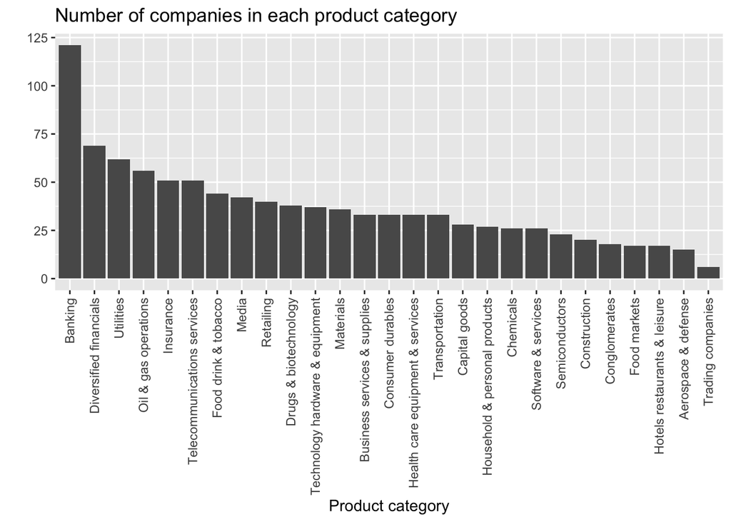

```r
companies %>%
  count(category) %>%
  ggplot(aes(x = reorder(category, -n), y = n)) +
  geom_col() +
  labs(title = "Number of companies in each product category",
       x = "Product category",
       y = "") +
  theme(axis.text.x = element_text(angle = 90, vjust = 0.5, hjust=1))
```

Based on the plot, the lowest number of companies are in the *Trading companies* category.

## Question 2

Consider product categories `Drugs & biotechnology` and `Media`. Create a visualization showing the profit given sales of each company with the following features:

- Different colors are used for each product category.
- Informative figure title and axis titles are given.
- A trend line for each category is added using `geom_smooth`.

Based on the trend lines which product category gives the best profit?

Guiding solution:

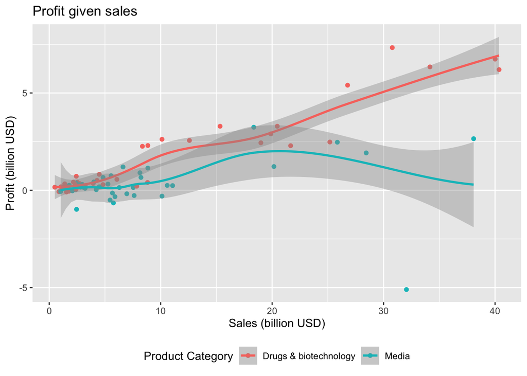

```r
companies %>%
  filter(category %in% c("Drugs & biotechnology", "Media")) %>%
  ggplot(aes(x = sales, y = profits, color = category)) +
  geom_point() +
  geom_smooth() +
  labs(title = "Profit given sales",
       x = "Sales (billion USD)",
       y = "Profit (billion USD)",
       color = "Product Category") +
  theme(legend.position = "bottom")
```

Based on the plot the *Drugs & biotechnology* product category gives the best profit.

## Question 3

Consider product categories `Banking` and `Aerospace & defense`. Let `ratio` denote a variable/column that equals profit divided by sales. Create a visualization showing the variation in `ratio` with the following features:

- Different colors are used for each product category.
- Informative figure title and axis titles are given.

Based on the visualization comment on the variation and median. Which product category gives the highest ratio?

Guiding solution:

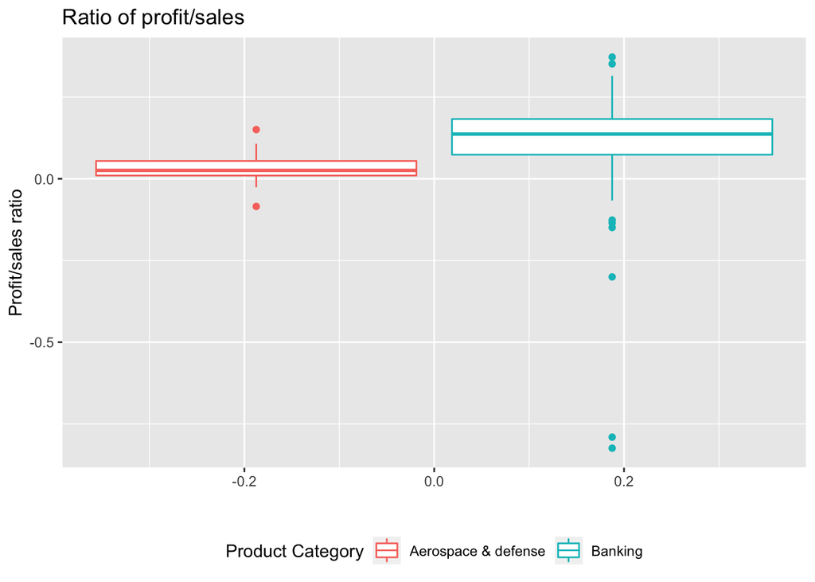

```r
companies <- companies %>%
  mutate(ratio = profits/sales)

# Option 1 - Use a boxplot
companies %>%
  filter(category %in% c("Banking", "Aerospace & defense")) %>%
  ggplot(aes(y = ratio, color = category)) +
  geom_boxplot() +
  labs(title = "Ratio of profit/sales",
       x = "",
       y = "Profit/sales ratio",
       color = "Product Category") +
  theme(legend.position = "bottom")
```

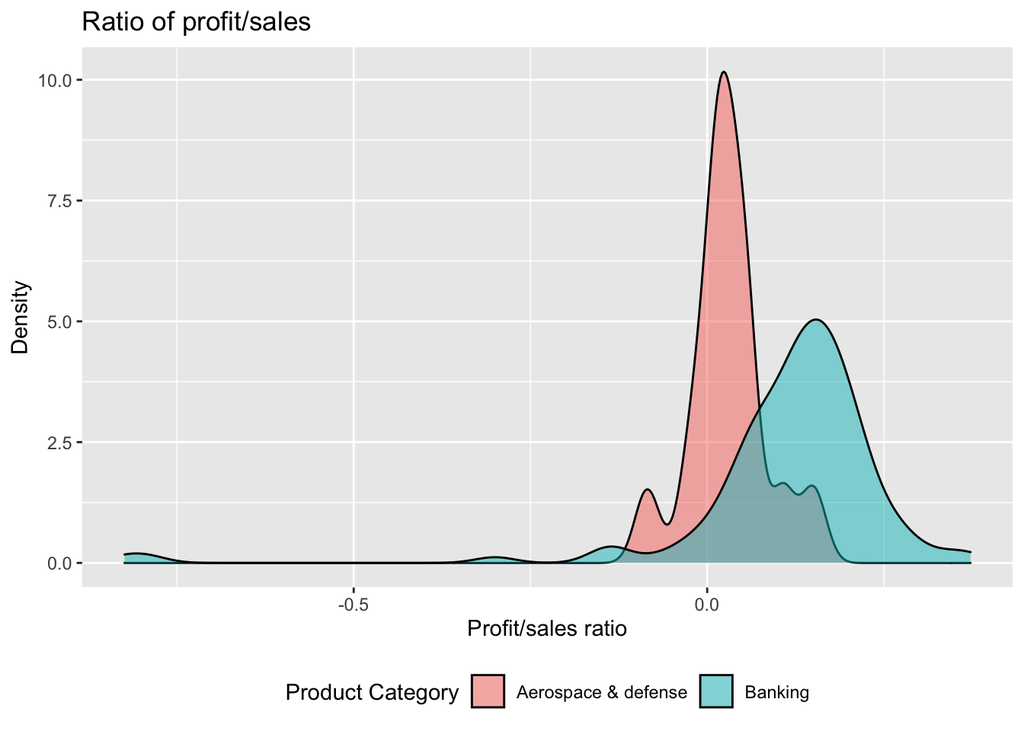

```r
# Option 2 - Use a density plot
companies %>%
  filter(category %in% c("Banking", "Aerospace & defense")) %>%
  ggplot(aes(x = ratio, fill = category)) +
  geom_density(alpha = 0.5) +
  labs(title = "Ratio of profit/sales",
       y = "Density",
       x = "Profit/sales ratio",
       fill = "Product Category") +
  theme(legend.position = "bottom")
```

Given the plot above, it can be seen that the highest ratio with respect to the mean and the median is for *Banking*. However, the variation is also highest here.

## Question 4

The `continents` dataset given in the appendix matches countries to continents and contains two columns:

- `country`: the country.
- `continent`: the corresponding continent.

You can load the dataset using:

```r
continents <- read_csv("continents.csv")
```

Consider product categories `Banking`, `Aerospace & defense`, `Telecommunications services` and `Semiconductors`. Create a visualization showing assets given market value for each company with the following features (hint: you may need to do a mutating join):

- Two continents `Americas` and `Europe` are considered.
- Different colors are used for each continent.
- A plot is given for each product category (facet).
- Informative figure title and axis titles are given.
- A trend line for each category is added using `geom_smooth(method = lm)`.

Based on the visualization consider the trend lines for *Banking* and comment.

Guiding solution:

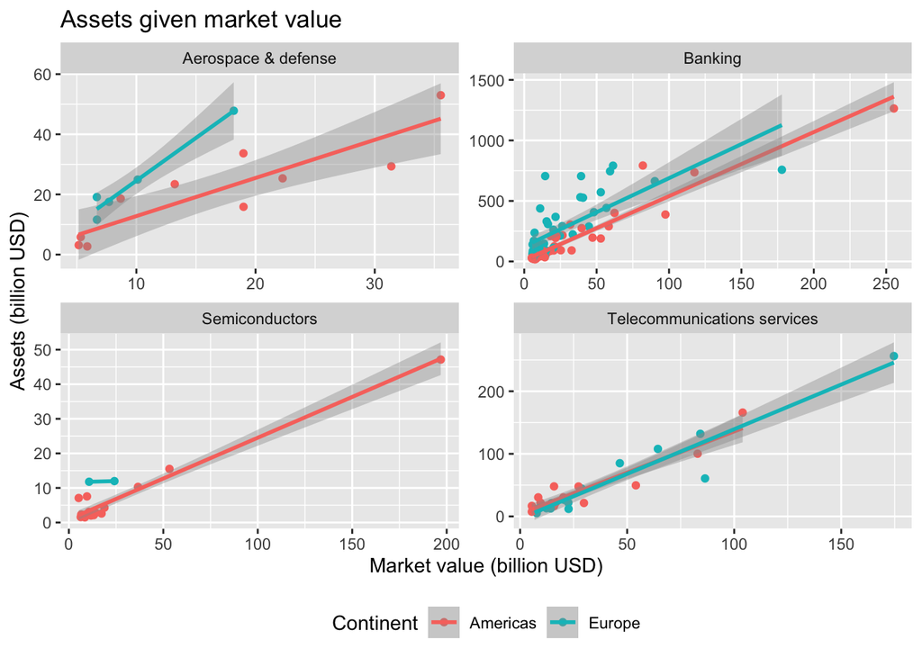

```r
companies %>%
  left_join(continents) %>%
  filter(continent %in% c("Americas", "Europe")) %>%
  filter(category %in% c("Banking", "Aerospace & defense",
                         "Telecommunications services", "Semiconductors")) %>%
  ggplot(aes(x = marketvalue, y = assets, color = continent)) +
  geom_point() +
  geom_smooth(method = lm) +
  facet_wrap(vars(category), scales = "free") +
  labs(title = "Assets given market value",
       x = "Market value (billion USD)",
       y = "Assets (billion USD)",
       color = "Continent") +
  theme(legend.position = "bottom")
```

By considering the trend lines for *Banking*, it seems that if compare companies with the same marketvalue, then companies in Europe have more assets.